# Codebook example with formr.org data

Ruben Arslan

2024-12-22

In this vignette, you can see what a codebook generated from a dataset with rich metadata looks like. This dataset includes mock data for a short German Big Five personality inventory and an age variable. The dataset follows the format created when importing data from formr.org. However, data imported using the `haven` package uses similar metadata. You can also add such metadata yourself, or use the codebook package for unannotated datasets.

As you can see below, the `codebook` package automatically computes reliabilities for multi-item inventories, generates nicely labelled plots and outputs summary statistics. The same information is also stored in a table, which you can export to various formats. Additionally, `codebook` can show you different kinds of (labelled) missing values, and show you common missingness patterns. As *you* cannot see, but *[search engines](https://datasetsearch.research.google.com)* will, the `codebook` package also generates [JSON-LD](https://json-ld.org/) metadata for the dataset. If you share your codebook as an HTML file online, this metadata should make it easier for others to find your data. [See what Google sees here](https://search.google.com/structured-data/testing-tool#url=https%3A%2F%2Frubenarslan.github.io%2Fcodebook%2Farticles%2Fcodebook.html).

```r
knit_by_pkgdown <- !is.null(knitr::opts_chunk$get("fig.retina"))
knitr::opts_chunk$set(warning = FALSE, message = TRUE, error = FALSE)
ggplot2::theme_set(ggplot2::theme_bw())

library(codebook)
data("bfi", package = 'codebook')
if (!knit_by_pkgdown) {
  library(dplyr)
    bfi <- bfi %>% select(-starts_with("BFIK_extra"),
                        -starts_with("BFIK_open"),
                        -starts_with("BFIK_consc"))
}
set.seed(1)
bfi$age <- rpois(nrow(bfi), 30)
library(labelled)
var_label(bfi$age) <- "Alter"
```

By default, we only set the required metadata attributes `name` and `description` to sensible values. However, there is a number of attributes you can set to describe the data better. [Find out more](https://developers.google.com/search/docs/data-types/dataset).

```r
metadata(bfi)$name <- "MOCK Big Five Inventory dataset (German metadata demo)"
metadata(bfi)$description <- "a small mock Big Five Inventory dataset"
metadata(bfi)$identifier <- "doi:10.5281/zenodo.1326520"
metadata(bfi)$datePublished <- "2016-06-01"
metadata(bfi)$creator <- list(
      "@type" = "Person",
      givenName = "Ruben", familyName = "Arslan",
      email = "ruben.arslan@gmail.com",
      affiliation = list("@type" = "Organization",
        name = "MPI Human Development, Berlin"))
metadata(bfi)$citation <- "Arslan (2016). Mock BFI data."
metadata(bfi)$url <- "https://rubenarslan.github.io/codebook/articles/codebook.html"
metadata(bfi)$temporalCoverage <- "2016"
metadata(bfi)$spatialCoverage <- "Goettingen, Germany"
```

```r
# We don't want to look at the code in the codebook.
knitr::opts_chunk$set(warning = TRUE, message = TRUE, echo = FALSE)
```

### Metadata

#### Description

**Dataset name**: MOCK Big Five Inventory dataset (German metadata demo)

a small mock Big Five Inventory dataset

**Metadata for search engines**

- **Temporal Coverage**: 2016
- **Spatial Coverage**: Goettingen, Germany
- **Citation**: Arslan (2016). Mock BFI data.
- **URL**: https://rubenarslan.github.io/codebook/articles/codebook.html
- **Identifier**: [doi:10.5281/zenodo.1326520](https://dx.doi.org/10.5281/zenodo.1326520)
- **Date published**: 2016-06-01
- **Creator**:

| name | value |
| --- | --- |
| @type | Person |
| givenName | Ruben |
| familyName | Arslan |
| email | ruben.arslan@gmail.com |
| affiliation | Organization , MPI Human Development, Berlin |

| x |
| --- |
| session |
| created |
| modified |
| ended |
| expired |
| BFIK_agree_4R |
| BFIK_agree_1R |
| BFIK_neuro_2R |
| BFIK_agree_3R |
| BFIK_neuro_3 |
| BFIK_neuro_4 |
| BFIK_agree_2 |
| BFIK_agree |
| BFIK_neuro |
| age |

### Survey overview

28 completed rows, 28 who entered any information, 0 only viewed the first page. There are 0 expired rows (people who did not finish filling out in the requested time frame). In total, there are 28 rows including unfinished and expired rows.

There were 28 unique participants, of which 28 finished filling out at least one survey.

This survey was not repeated.

The first session started on 2016-07-08 09:54:16, the last session on 2016-11-02 21:19:50.

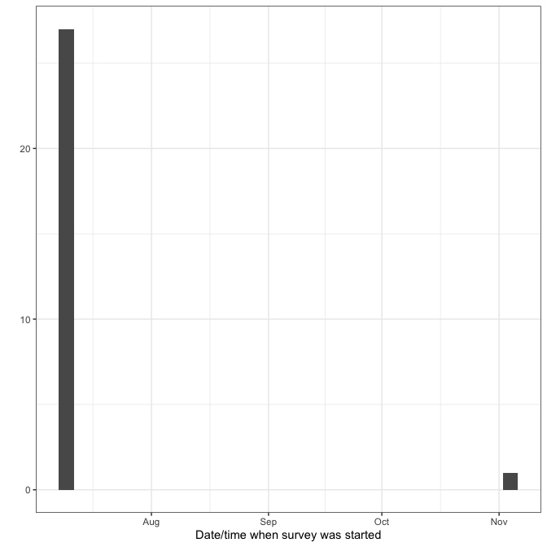

Starting date times

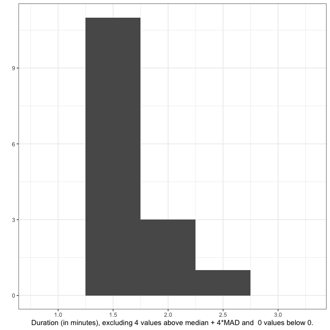

Duration people took for answering the survey

## Variables

### Scale: BFIK_agree

#### Overview

**Reliability**: Cronbach’s α [95% CI] = 0.8 [0.68;0.92].

**Missing**: 0.

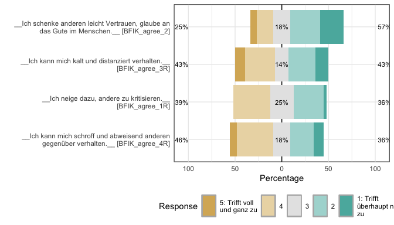

Likert plot of scale BFIK_agree items

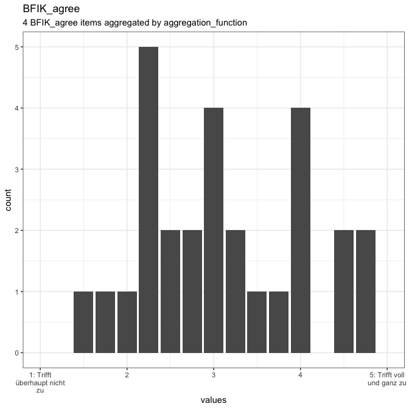

Distribution of scale BFIK_agree

#### Reliability details

###### 95% Confidence Interval

| lower | estimate | upper |
| --- | --- | --- |
| 0.6815382 | 0.8005842 | 0.9196302 |

|  | raw_alpha | std.alpha | G6(smc) | average_r | S/N | ase | mean | sd | median_r |
| --- | --- | --- | --- | --- | --- | --- | --- | --- | --- |
|  | 0.8005842 | 0.8032578 | 0.8025354 | 0.5051216 | 4.082794 | 0.0607377 | 3.116071 | 0.9316506 | 0.4955289 |

###### Reliability if an item is dropped:

|  | raw_alpha | std.alpha | G6(smc) | average_r | S/N | alpha se | var.r | med.r |
| --- | --- | --- | --- | --- | --- | --- | --- | --- |
| BFIK_agree_4R | 0.7039106 | 0.7059214 | 0.6277253 | 0.4444909 | 2.400452 | 0.0922357 | 0.0093288 | 0.4566167 |
| BFIK_agree_1R | 0.7822898 | 0.7821901 | 0.7633114 | 0.5448449 | 3.591160 | 0.0731005 | 0.0413123 | 0.5344410 |
| BFIK_agree_3R | 0.6758982 | 0.6925559 | 0.6242359 | 0.4288568 | 2.252623 | 0.1072194 | 0.0212505 | 0.3469923 |
| BFIK_agree_2 | 0.8180575 | 0.8196006 | 0.7841113 | 0.6022937 | 4.543256 | 0.0568475 | 0.0219955 | 0.5971631 |

###### Item statistics

|  | n | raw.r | std.r | r.cor | r.drop | mean | sd |
| --- | --- | --- | --- | --- | --- | --- | --- |
| BFIK_agree_4R | 28 | 0.8471206 | 0.8503385 | 0.8291974 | 0.7057555 | 2.928571 | 1.184110 |
| BFIK_agree_1R | 28 | 0.7168171 | 0.7554255 | 0.6253942 | 0.5538583 | 3.000000 | 0.942809 |
| BFIK_agree_3R | 28 | 0.8820884 | 0.8651249 | 0.8439281 | 0.7510051 | 3.035714 | 1.290482 |
| BFIK_agree_2 | 28 | 0.7205961 | 0.7010915 | 0.5430779 | 0.4825103 | 3.500000 | 1.261980 |

###### Non missing response frequency for each item

|  | 1 | 2 | 3 | 4 | 5 | miss |
| --- | --- | --- | --- | --- | --- | --- |
| BFIK_agree_4R | 0.0714286 | 0.3928571 | 0.1785714 | 0.2500000 | 0.1071429 | 0 |
| BFIK_agree_1R | 0.0000000 | 0.3928571 | 0.2500000 | 0.3214286 | 0.0357143 | 0 |
| BFIK_agree_3R | 0.1071429 | 0.3214286 | 0.1428571 | 0.2857143 | 0.1428571 | 0 |
| BFIK_agree_2 | 0.0714286 | 0.1785714 | 0.1785714 | 0.3214286 | 0.2500000 | 0 |

#### Summary statistics

| name | label | type | type_options | data_type | value_labels | optional | item_order | n_missing | complete_rate | min | median | max | mean | sd | n_value_labels | hist |
| --- | --- | --- | --- | --- | --- | --- | --- | --- | --- | --- | --- | --- | --- | --- | --- | --- |
| BFIK_agree_4R | **Ich kann mich schroff und abweisend anderen gegenüber verhalten.** | rating_button | 5 | haven_labelled | 5. 1: Trifft überhaupt nicht zu, 4. 2, 3. 3, 2. 4, 1. 5: Trifft voll und ganz zu, NA. Item was never rendered for this user. | 0 | 5 | 0 | 1 | 1 | 3 | 5 | 2.928571 | 1.184110 | 6 | ▂▇▁▃▁▅▁▂ |
| BFIK_agree_1R | **Ich neige dazu, andere zu kritisieren.** | rating_button | 5 | haven_labelled | 5. 1: Trifft überhaupt nicht zu, 4. 2, 3. 3, 2. 4, 1. 5: Trifft voll und ganz zu, NA. Item was never rendered for this user. | 0 | 7 | 0 | 1 | 2 | 3 | 5 | 3.000000 | 0.942809 | 6 | ▇▁▅▁▁▆▁▁ |
| BFIK_agree_3R | **Ich kann mich kalt und distanziert verhalten.** | rating_button | 5 | haven_labelled | 5. 1: Trifft überhaupt nicht zu, 4. 2, 3. 3, 2. 4, 1. 5: Trifft voll und ganz zu, NA. Item was never rendered for this user. | 0 | 13 | 0 | 1 | 1 | 3 | 5 | 3.035714 | 1.290482 | 6 | ▂▇▁▃▁▇▁▃ |
| BFIK_agree_2 | **Ich schenke anderen leicht Vertrauen, glaube an das Gute im Menschen.** | rating_button | 5 | haven_labelled | 1. 1: Trifft überhaupt nicht zu, 2. 2, 3. 3, 4. 4, 5. 5: Trifft voll und ganz zu, NA. Item was never rendered for this user. | 0 | 17 | 0 | 1 | 1 | 4 | 5 | 3.500000 | 1.261980 | 6 | ▂▅▁▅▁▇▁▆ |

### Scale: BFIK_neuro

#### Overview

**Reliability**: Cronbach’s α [95% CI] = 0.75 [0.61;0.9].

**Missing**: 0.

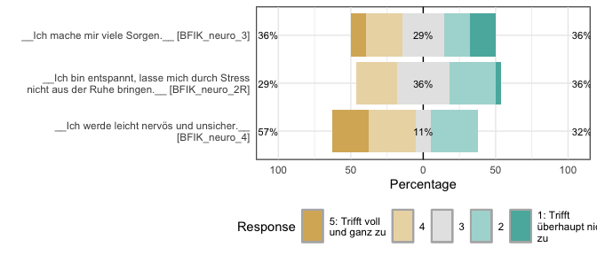

Likert plot of scale BFIK_neuro items

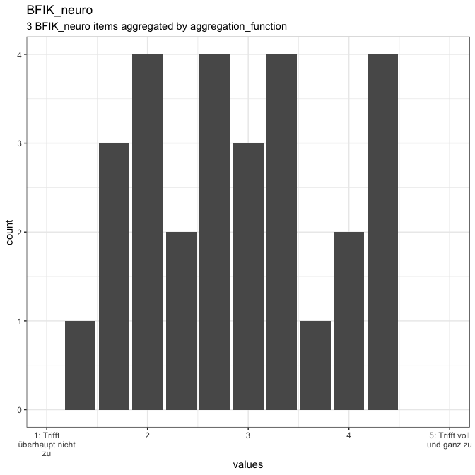

Distribution of scale BFIK_neuro

#### Reliability details

###### 95% Confidence Interval

| lower | estimate | upper |
| --- | --- | --- |
| 0.6080638 | 0.7537326 | 0.8994015 |

|  | raw_alpha | std.alpha | G6(smc) | average_r | S/N | ase | mean | sd | median_r |
| --- | --- | --- | --- | --- | --- | --- | --- | --- | --- |
|  | 0.7537326 | 0.7476172 | 0.7145893 | 0.496833 | 2.962235 | 0.0743208 | 2.892857 | 0.9254231 | 0.440167 |

###### Reliability if an item is dropped:

|  | raw_alpha | std.alpha | G6(smc) | average_r | S/N | alpha se | var.r | med.r |
| --- | --- | --- | --- | --- | --- | --- | --- | --- |
| BFIK_neuro_2R | 0.8400000 | 0.8408387 | 0.7253854 | 0.7253854 | 5.2829328 | 0.0602555 | NA | 0.7253854 |
| BFIK_neuro_3 | 0.5904682 | 0.6112721 | 0.4401670 | 0.4401670 | 1.5724937 | 0.1456732 | NA | 0.4401670 |
| BFIK_neuro_4 | 0.4653928 | 0.4905053 | 0.3249467 | 0.3249467 | 0.9627289 | 0.1871605 | NA | 0.3249467 |

###### Item statistics

|  | n | raw.r | std.r | r.cor | r.drop | mean | sd |
| --- | --- | --- | --- | --- | --- | --- | --- |
| BFIK_neuro_2R | 28 | 0.6549435 | 0.7217484 | 0.4638430 | 0.4100297 | 3.107143 | 0.8751417 |
| BFIK_neuro_3 | 28 | 0.8755182 | 0.8383732 | 0.7625955 | 0.6528603 | 3.071429 | 1.2744954 |
| BFIK_neuro_4 | 28 | 0.9046526 | 0.8854863 | 0.8409166 | 0.7420620 | 2.500000 | 1.2018504 |

###### Non missing response frequency for each item

|  | 1 | 2 | 3 | 4 | 5 | miss |
| --- | --- | --- | --- | --- | --- | --- |
| BFIK_neuro_2R | 0.0000000 | 0.2857143 | 0.3571429 | 0.3214286 | 0.0357143 | 0 |
| BFIK_neuro_3 | 0.1071429 | 0.2500000 | 0.2857143 | 0.1785714 | 0.1785714 | 0 |
| BFIK_neuro_4 | 0.2500000 | 0.3214286 | 0.1071429 | 0.3214286 | 0.0000000 | 0 |

#### Summary statistics

| name | label | type | type_options | data_type | value_labels | optional | item_order | n_missing | complete_rate | min | median | max | mean | sd | n_value_labels | hist |
| --- | --- | --- | --- | --- | --- | --- | --- | --- | --- | --- | --- | --- | --- | --- | --- | --- |
| BFIK_neuro_2R | **Ich bin entspannt, lasse mich durch Stress nicht aus der Ruhe bringen.** | rating_button | 5 | haven_labelled | 5. 1: Trifft überhaupt nicht zu, 4. 2, 3. 3, 2. 4, 1. 5: Trifft voll und ganz zu, NA. Item was never rendered for this user. | 0 | 9 | 0 | 1 | 2 | 3 | 5 | 3.107143 | 0.8751417 | 6 | ▆▁▇▁▁▇▁▁ |
| BFIK_neuro_3 | **Ich mache mir viele Sorgen.** | rating_button | 5 | haven_labelled | 1. 1: Trifft überhaupt nicht zu, 2. 2, 3. 3, 4. 4, 5. 5: Trifft voll und ganz zu, NA. Item was never rendered for this user. | 0 | 15 | 0 | 1 | 1 | 3 | 5 | 3.071429 | 1.2744954 | 6 | ▃▇▁▇▁▅▁▅ |
| BFIK_neuro_4 | **Ich werde leicht nervös und unsicher.** | rating_button | 5 | haven_labelled | 1. 1: Trifft überhaupt nicht zu, 2. 2, 3. 3, 4. 4, 5. 5: Trifft voll und ganz zu, NA. Item was never rendered for this user. | 0 | 16 | 0 | 1 | 1 | 2 | 4 | 2.500000 | 1.2018504 | 6 | ▆▁▇▁▁▂▁▇ |

### age

Alter

#### Distribution

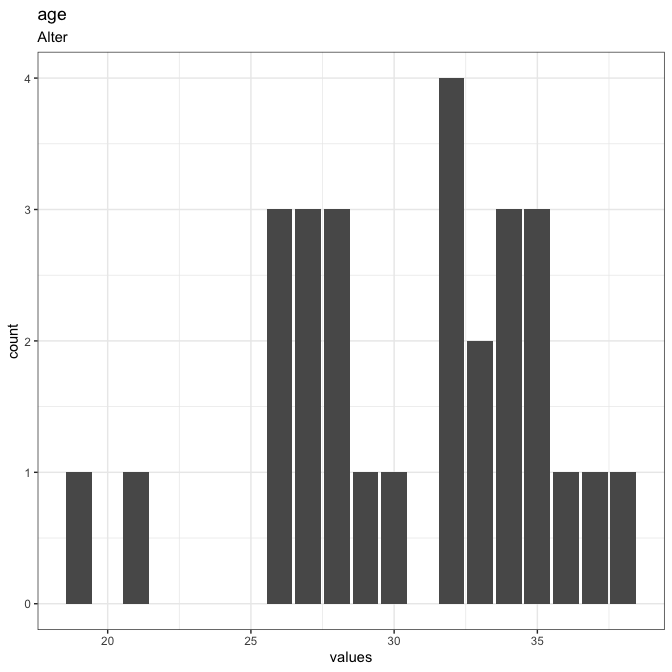

Distribution of values for age

0 missing values.

#### Summary statistics

| name | label | data_type | n_missing | complete_rate | min | median | max | mean | sd | hist |
| --- | --- | --- | --- | --- | --- | --- | --- | --- | --- | --- |
| age | Alter | numeric | 0 | 1 | 19 | 32 | 38 | 30.5 | 4.670633 | ▂▂▇▇▅ |

## Missingness report

| description | expired | var_miss | n_miss |
| --- | --- | --- | --- |
| Missing values in 1 variables | 0 | 1 | 28 |
| Missing values per variable | 28 | 28 | 28 |

**JSON-LD metadata**

The following JSON-LD can be found by search engines, if you share this codebook publicly on the web.

```json
{
  "name": "MOCK Big Five Inventory dataset (German metadata demo)",
  "description": "a small mock Big Five Inventory dataset\n\n\n## Table of variables\nThis table contains variable names, labels, and number of missing values.\nSee the complete codebook for more.\n\n|name          |label                                                                      | n_missing|\n|:-------------|:--------------------------------------------------------------------------|---------:|\n|session       |NA                                                                         |         0|\n|created       |user first opened survey                                                   |         0|\n|modified      |user last edited survey                                                    |         0|\n|ended         |user finished survey                                                       |         0|\n|expired       |NA                                                                         |        28|\n|BFIK_agree_4R |__Ich kann mich schroff und abweisend anderen gegenüber verhalten.__       |         0|\n|BFIK_agree_1R |__Ich neige dazu, andere zu kritisieren.__                                 |         0|\n|BFIK_neuro_2R |__Ich bin entspannt, lasse mich durch Stress nicht aus der Ruhe bringen.__ |         0|\n|BFIK_agree_3R |__Ich kann mich kalt und distanziert verhalten.__                          |         0|\n|BFIK_neuro_3  |__Ich mache mir viele Sorgen.__                                            |         0|\n|BFIK_neuro_4  |__Ich werde leicht nervös und unsicher.__                                  |         0|\n|BFIK_agree_2  |__Ich schenke anderen leicht Vertrauen, glaube an das Gute im Menschen.__  |         0|\n|BFIK_agree    |4 BFIK_agree items aggregated by aggregation_function                      |         0|\n|BFIK_neuro    |3 BFIK_neuro items aggregated by aggregation_function                      |         0|\n|age           |Alter                                                                      |         0|\n\n### Note\nThis dataset was automatically described using the [codebook R package](https://rubenarslan.github.io/codebook/) (version 0.9.5).",
  "identifier": "doi:10.5281/zenodo.1326520",
  "datePublished": "2016-06-01",
  "creator": {
    "@type": "Person",
    "givenName": "Ruben",
    "familyName": "Arslan",
    "email": "ruben.arslan@gmail.com",
    "affiliation": {
      "@type": "Organization",
      "name": "MPI Human Development, Berlin"
    }
  },
  "citation": "Arslan (2016). Mock BFI data.",
  "url": "https://rubenarslan.github.io/codebook/articles/codebook.html",
  "temporalCoverage": "2016",
  "spatialCoverage": "Goettingen, Germany",
  "keywords": ["session", "created", "modified", "ended", "expired", "BFIK_agree_4R", "BFIK_agree_1R", "BFIK_neuro_2R", "BFIK_agree_3R", "BFIK_neuro_3", "BFIK_neuro_4", "BFIK_agree_2", "BFIK_agree", "BFIK_neuro", "age"],
  "@context": "https://schema.org/",
  "@type": "Dataset",
  "variableMeasured": [
    {
      "name": "session",
      "@type": "propertyValue"
    },
    {
      "name": "created",
      "description": "user first opened survey",
      "@type": "propertyValue"
    },
    {
      "name": "modified",
      "description": "user last edited survey",
      "@type": "propertyValue"
    },
    {
      "name": "ended",
      "description": "user finished survey",
      "@type": "propertyValue"
    },
    {
      "name": "expired",
      "@type": "propertyValue"
    },
    {
      "name": "BFIK_agree_4R",
      "description": "__Ich kann mich schroff und abweisend anderen gegenüber verhalten.__",
      "value": "5. 1: Trifft überhaupt nicht zu,\n4. 2,\n3. 3,\n2. 4,\n1. 5: Trifft voll und ganz zu,\nNA. Item was never rendered for this user.",
      "maxValue": 5,
      "minValue": 1,
      "measurementTechnique": "self-report",
      "@type": "propertyValue"
    },
    {
      "name": "BFIK_agree_1R",
      "description": "__Ich neige dazu, andere zu kritisieren.__",
      "value": "5. 1: Trifft überhaupt nicht zu,\n4. 2,\n3. 3,\n2. 4,\n1. 5: Trifft voll und ganz zu,\nNA. Item was never rendered for this user.",
      "maxValue": 5,
      "minValue": 1,
      "measurementTechnique": "self-report",
      "@type": "propertyValue"
    },
    {
      "name": "BFIK_neuro_2R",
      "description": "__Ich bin entspannt, lasse mich durch Stress nicht aus der Ruhe bringen.__",
      "value": "5. 1: Trifft überhaupt nicht zu,\n4. 2,\n3. 3,\n2. 4,\n1. 5: Trifft voll und ganz zu,\nNA. Item was never rendered for this user.",
      "maxValue": 5,
      "minValue": 1,
      "measurementTechnique": "self-report",
      "@type": "propertyValue"
    },
    {
      "name": "BFIK_agree_3R",
      "description": "__Ich kann mich kalt und distanziert verhalten.__",
      "value": "5. 1: Trifft überhaupt nicht zu,\n4. 2,\n3. 3,\n2. 4,\n1. 5: Trifft voll und ganz zu,\nNA. Item was never rendered for this user.",
      "maxValue": 5,
      "minValue": 1,
      "measurementTechnique": "self-report",
      "@type": "propertyValue"
    },
    {
      "name": "BFIK_neuro_3",
      "description": "__Ich mache mir viele Sorgen.__",
      "value": "1. 1: Trifft überhaupt nicht zu,\n2. 2,\n3. 3,\n4. 4,\n5. 5: Trifft voll und ganz zu,\nNA. Item was never rendered for this user.",
      "maxValue": 5,
      "minValue": 1,
      "measurementTechnique": "self-report",
      "@type": "propertyValue"
    },
    {
      "name": "BFIK_neuro_4",
      "description": "__Ich werde leicht nervös und unsicher.__",
      "value": "1. 1: Trifft überhaupt nicht zu,\n2. 2,\n3. 3,\n4. 4,\n5. 5: Trifft voll und ganz zu,\nNA. Item was never rendered for this user.",
      "maxValue": 5,
      "minValue": 1,
      "measurementTechnique": "self-report",
      "@type": "propertyValue"
    },
    {
      "name": "BFIK_agree_2",
      "description": "__Ich schenke anderen leicht Vertrauen, glaube an das Gute im Menschen.__",
      "value": "1. 1: Trifft überhaupt nicht zu,\n2. 2,\n3. 3,\n4. 4,\n5. 5: Trifft voll und ganz zu,\nNA. Item was never rendered for this user.",
      "maxValue": 5,
      "minValue": 1,
      "measurementTechnique": "self-report",
      "@type": "propertyValue"
    },
    {
      "name": "BFIK_agree",
      "description": "4 BFIK_agree items aggregated by aggregation_function",
      "@type": "propertyValue"
    },
    {
      "name": "BFIK_neuro",
      "description": "3 BFIK_neuro items aggregated by aggregation_function",
      "@type": "propertyValue"
    },
    {
      "name": "age",
      "description": "Alter",
      "@type": "propertyValue"
    }
  ]
}`
```

### Codebook table

| name | label | type | type_options | data_type | value_labels | optional | scale_item_names | item_order | n_missing | complete_rate | n_unique | empty | count | min | median | max | mean | sd | whitespace | n_value_labels | hist |
| --- | --- | --- | --- | --- | --- | --- | --- | --- | --- | --- | --- | --- | --- | --- | --- | --- | --- | --- | --- | --- | --- |
| session | NA | NA | NA | character | NA | NA | NA | NA | 0 | 1 | 28 | 0 | NA | 64 | NA | 64 | NA | NA | 0 | NA | NA |
| created | user first opened survey | NA | NA | POSIXct | NA | NA | NA | NA | 0 | 1 | 28 | NA | NA | 2016-07-08 09:54:16 | 2016-07-08 12:47:07.5 | 2016-11-02 21:19:50 | NA | NA | NA | NA | NA |
| modified | user last edited survey | NA | NA | POSIXct | NA | NA | NA | NA | 0 | 1 | 28 | NA | NA | 2016-07-08 09:55:43 | 2016-07-08 14:23:22.5 | 2016-11-02 21:21:53 | NA | NA | NA | NA | NA |
| ended | user finished survey | NA | NA | POSIXct | NA | NA | NA | NA | 0 | 1 | 28 | NA | NA | 2016-07-08 09:55:43 | 2016-07-08 14:23:22.5 | 2016-11-02 21:21:53 | NA | NA | NA | NA | NA |
| expired | NA | NA | NA | logical | NA | NA | NA | NA | 28 | 0 | NA | NA | : | NA | NA | NA | NaN | NA | NA | NA | NA |
| BFIK_agree_4R | **Ich kann mich schroff und abweisend anderen gegenüber verhalten.** | rating_button | 5 | haven_labelled | 5. 1: Trifft überhaupt nicht zu, 4. 2, 3. 3, 2. 4, 1. 5: Trifft voll und ganz zu, NA. Item was never rendered for this user. | 0 | NA | 5 | 0 | 1 | NA | NA | NA | 1 | 3 | 5 | 2.928571 | 1.1841100 | NA | 6 | ▂▇▁▃▁▅▁▂ |
| BFIK_agree_1R | **Ich neige dazu, andere zu kritisieren.** | rating_button | 5 | haven_labelled | 5. 1: Trifft überhaupt nicht zu, 4. 2, 3. 3, 2. 4, 1. 5: Trifft voll und ganz zu, NA. Item was never rendered for this user. | 0 | NA | 7 | 0 | 1 | NA | NA | NA | 2 | 3 | 5 | 3.000000 | 0.9428090 | NA | 6 | ▇▁▅▁▁▆▁▁ |
| BFIK_neuro_2R | **Ich bin entspannt, lasse mich durch Stress nicht aus der Ruhe bringen.** | rating_button | 5 | haven_labelled | 5. 1: Trifft überhaupt nicht zu, 4. 2, 3. 3, 2. 4, 1. 5: Trifft voll und ganz zu, NA. Item was never rendered for this user. | 0 | NA | 9 | 0 | 1 | NA | NA | NA | 2 | 3 | 5 | 3.107143 | 0.8751417 | NA | 6 | ▆▁▇▁▁▇▁▁ |
| BFIK_agree_3R | **Ich kann mich kalt und distanziert verhalten.** | rating_button | 5 | haven_labelled | 5. 1: Trifft überhaupt nicht zu, 4. 2, 3. 3, 2. 4, 1. 5: Trifft voll und ganz zu, NA. Item was never rendered for this user. | 0 | NA | 13 | 0 | 1 | NA | NA | NA | 1 | 3 | 5 | 3.035714 | 1.2904820 | NA | 6 | ▂▇▁▃▁▇▁▃ |
| BFIK_neuro_3 | **Ich mache mir viele Sorgen.** | rating_button | 5 | haven_labelled | 1. 1: Trifft überhaupt nicht zu, 2. 2, 3. 3, 4. 4, 5. 5: Trifft voll und ganz zu, NA. Item was never rendered for this user. | 0 | NA | 15 | 0 | 1 | NA | NA | NA | 1 | 3 | 5 | 3.071429 | 1.2744954 | NA | 6 | ▃▇▁▇▁▅▁▅ |
| BFIK_neuro_4 | **Ich werde leicht nervös und unsicher.** | rating_button | 5 | haven_labelled | 1. 1: Trifft überhaupt nicht zu, 2. 2, 3. 3, 4. 4, 5. 5: Trifft voll und ganz zu, NA. Item was never rendered for this user. | 0 | NA | 16 | 0 | 1 | NA | NA | NA | 1 | 2 | 4 | 2.500000 | 1.2018504 | NA | 6 | ▆▁▇▁▁▂▁▇ |
| BFIK_agree_2 | **Ich schenke anderen leicht Vertrauen, glaube an das Gute im Menschen.** | rating_button | 5 | haven_labelled | 1. 1: Trifft überhaupt nicht zu, 2. 2, 3. 3, 4. 4, 5. 5: Trifft voll und ganz zu, NA. Item was never rendered for this user. | 0 | NA | 17 | 0 | 1 | NA | NA | NA | 1 | 4 | 5 | 3.500000 | 1.2619796 | NA | 6 | ▂▅▁▅▁▇▁▆ |
| BFIK_agree | 4 BFIK_agree items aggregated by aggregation_function | NA | NA | numeric | NA | NA | BFIK_agree_4R, BFIK_agree_1R, BFIK_agree_3R, BFIK_agree_2 | NA | 0 | 1 | NA | NA | NA | 1.5 | 3.0 | 4.8 | 3.116071 | 0.9316506 | NA | NA | ▂▇▅▅▃ |
| BFIK_neuro | 3 BFIK_neuro items aggregated by aggregation_function | NA | NA | numeric | NA | NA | BFIK_neuro_2R, BFIK_neuro_3, BFIK_neuro_4 | NA | 0 | 1 | NA | NA | NA | 1.3 | 2.8 | 4.3 | 2.892857 | 0.9254231 | NA | NA | ▅▇▇▆▇ |
| age | Alter | NA | NA | numeric | NA | NA | NA | NA | 0 | 1 | NA | NA | NA | 19.0 | 32.0 | 38.0 | 30.500000 | 4.6706332 | NA | NA | ▂▂▇▇▅ |